# Homework 6 Solutions

Alexandra Chronopoulou

4/1/2021

### Problem 1

The `aatemp` data in the *faraway* library come from the U.S. Historical Climatological Network. They are the annual mean temperatures (in degrees F) in Ann Arbor Michigan, going back about 150 years.

```r
library(faraway)
library(lmtest)
library(nlme)
library(splines)
data(aatemp)
head(aatemp)
```

```
##   year  temp
## 1 1854 49.15
## 2 1855 46.52
## 3 1871 48.80
## 4 1881 47.95
## 5 1882 47.31
## 6 1883 44.64
```

1. Is there a linear trend?

   To determine whether there is a linear trend, we can plot the data together with the regression line.

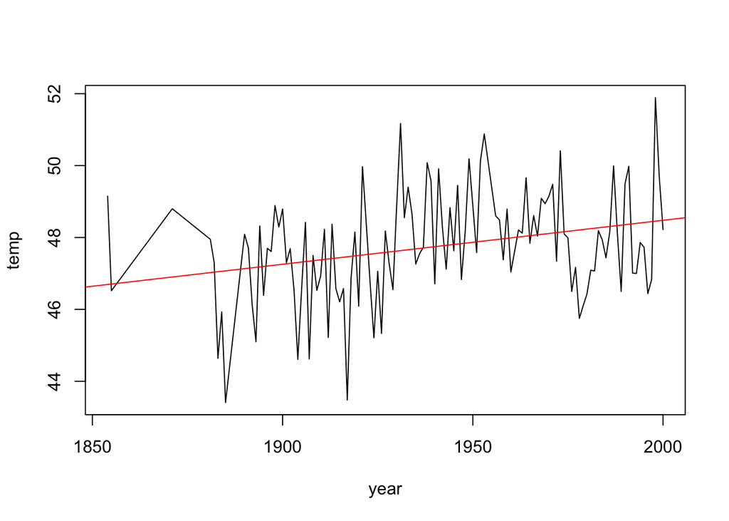

   ```r
   plot(temp~year,data=aatemp,type="l")
   modl<-lm(temp~year,data=aatemp)
   abline(coef(modl),col="red")
   ```

   ```r
   summary(modl)
   ```

   ```
   ##
   ## Call:
   ## lm(formula = temp ~ year, data = aatemp)
   ##
   ## Residuals:
   ##     Min      1Q  Median      3Q     Max
   ## -3.9843 -0.9113 -0.0820  0.9946  3.5343
   ##
   ## Coefficients:
   ##              Estimate Std. Error t value Pr(>|t|)
   ## (Intercept) 24.005510   7.310781   3.284  0.00136 **
   ## year         0.012237   0.003768   3.247  0.00153 **
   ## ---
   ## Signif. codes:  0 '***' 0.001 '**' 0.01 '*' 0.05 '.' 0.1 ' ' 1
   ##
   ## Residual standard error: 1.466 on 113 degrees of freedom
   ## Multiple R-squared:  0.08536,    Adjusted R-squared:  0.07727
   ## F-statistic: 10.55 on 1 and 113 DF,  p-value: 0.001533
   ```

   The linear trend is significant and positive. There is a significant increase of 0.122 F degrees per decade.
2. Observations in successive years may be correlated. Fit the model that estimates this correlation using generalized least squares. Does this change your opinion about the trend?

   We can first test to see whether there exists serial correlation in the data:

   ```r
   dwtest(temp~year,data=aatemp)
   ```

   ```
   ##
   ##  Durbin-Watson test
   ##
   ## data:  temp ~ year
   ## DW = 1.6177, p-value = 0.01524
   ## alternative hypothesis: true autocorrelation is greater than 0
   ```

   The test suggests that the errors are correlated.

   ```r
   modg<-gls(temp~year,correlation = corARMA(p=1),data=aatemp)
   summary(modg)
   ```

   ```
   ## Generalized least squares fit by REML
   ##   Model: temp ~ year
   ##   Data: aatemp
   ##        AIC     BIC    logLik
   ##   427.2854 438.195 -209.6427
   ##
   ## Correlation Structure: AR(1)
   ##  Formula: ~1
   ##  Parameter estimate(s):
   ##       Phi
   ## 0.2029313
   ##
   ## Coefficients:
   ##                 Value Std.Error  t-value p-value
   ## (Intercept) 24.604907  8.935293 2.753677  0.0069
   ## year         0.011931  0.004606 2.590398  0.0108
   ##
   ##  Correlation:
   ##      (Intr)
   ## year -1
   ##
   ## Standardized residuals:
   ##         Min          Q1         Med          Q3         Max
   ## -2.71297226 -0.62233530 -0.04994469  0.67429317  2.39436044
   ##
   ## Residual standard error: 1.472974
   ## Degrees of freedom: 115 total; 113 residual
   ```

   ```r
   intervals(modg)
   ```

   ```
   ## Approximate 95% confidence intervals
   ##
   ##  Coefficients:
   ##                   lower        est.       upper
   ## (Intercept) 6.902479686 24.60490705 42.30733440
   ## year        0.002805908  0.01193074  0.02105558
   ## attr(,"label")
   ## [1] "Coefficients:"
   ##
   ##  Correlation structure:
   ##          lower      est.     upper
   ## Phi 0.01312881 0.2029313 0.3786187
   ## attr(,"label")
   ## [1] "Correlation structure:"
   ##
   ##  Residual standard error:
   ##    lower     est.    upper
   ## 1.284139 1.472974 1.689578
   ```

   ```r
   modp<-lm(temp~year + I(year^2)+I(year^2)+I(year^3)+I(year^4)+I(year^5)+I(year^6)+I(year^7)+I(year^8)+I(year^9)+I(year^10),data=aatemp)
   summary(modp)
   ```

   ```
   ##
   ## Call:
   ## lm(formula = temp ~ year + I(year^2) + I(year^2) + I(year^3) +
   ##     I(year^4) + I(year^5) + I(year^6) + I(year^7) + I(year^8) +
   ##     I(year^9) + I(year^10), data = aatemp)
   ##
   ## Residuals:
   ##     Min      1Q  Median      3Q     Max
   ## -3.7126 -0.9175 -0.1441  0.9905  3.2313
   ##
   ## Coefficients: (5 not defined because of singularities)
   ##               Estimate Std. Error t value Pr(>|t|)
   ## (Intercept) -7.049e+07  2.972e+07  -2.372   0.0194 *
   ## year         1.676e+05  7.047e+04   2.379   0.0191 *
   ## I(year^2)   -1.526e+02  6.396e+01  -2.385   0.0188 *
   ## I(year^3)    6.347e-02  2.653e-02   2.392   0.0185 *
   ## I(year^4)   -1.031e-05  4.299e-06  -2.399   0.0182 *
   ## I(year^5)           NA         NA      NA       NA
   ## I(year^6)           NA         NA      NA       NA
   ## I(year^7)           NA         NA      NA       NA
   ## I(year^8)    1.074e-20  4.432e-21   2.423   0.0170 *
   ## I(year^9)           NA         NA      NA       NA
   ## I(year^10)          NA         NA      NA       NA
   ## ---
   ## Signif. codes:  0 '***' 0.001 '**' 0.01 '*' 0.05 '.' 0.1 ' ' 1
   ##
   ## Residual standard error: 1.4 on 109 degrees of freedom
   ## Multiple R-squared:  0.1955, Adjusted R-squared:  0.1586
   ## F-statistic: 5.298 on 5 and 109 DF,  p-value: 0.0002141
   ```

   ```r
   summary(modp1<-update(modp,.~.-I(year^10)))
   ```

   ```
   ##
   ## Call:
   ## lm(formula = temp ~ year + I(year^2) + I(year^3) + I(year^4) +
   ##     I(year^5) + I(year^6) + I(year^7) + I(year^8) + I(year^9),
   ##     data = aatemp)
   ##
   ## Residuals:
   ##     Min      1Q  Median      3Q     Max
   ## -3.7126 -0.9175 -0.1441  0.9905  3.2313
   ##
   ## Coefficients: (4 not defined because of singularities)
   ##               Estimate Std. Error t value Pr(>|t|)
   ## (Intercept) -7.049e+07  2.972e+07  -2.372   0.0194 *
   ## year         1.676e+05  7.047e+04   2.379   0.0191 *
   ## I(year^2)   -1.526e+02  6.396e+01  -2.385   0.0188 *
   ## I(year^3)    6.347e-02  2.653e-02   2.392   0.0185 *
   ## I(year^4)   -1.031e-05  4.299e-06  -2.399   0.0182 *
   ## I(year^5)           NA         NA      NA       NA
   ## I(year^6)           NA         NA      NA       NA
   ## I(year^7)           NA         NA      NA       NA
   ## I(year^8)    1.074e-20  4.432e-21   2.423   0.0170 *
   ## I(year^9)           NA         NA      NA       NA
   ## ---
   ## Signif. codes:  0 '***' 0.001 '**' 0.01 '*' 0.05 '.' 0.1 ' ' 1
   ##
   ## Residual standard error: 1.4 on 109 degrees of freedom
   ## Multiple R-squared:  0.1955, Adjusted R-squared:  0.1586
   ## F-statistic: 5.298 on 5 and 109 DF,  p-value: 0.0002141
   ```

   ```r
   summary(modp2<-update(modp1,.~.-I(year^9)))
   ```

   ```
   ##
   ## Call:
   ## lm(formula = temp ~ year + I(year^2) + I(year^3) + I(year^4) +
   ##     I(year^5) + I(year^6) + I(year^7) + I(year^8), data = aatemp)
   ##
   ## Residuals:
   ##     Min      1Q  Median      3Q     Max
   ## -3.7126 -0.9175 -0.1441  0.9905  3.2313
   ##
   ## Coefficients: (3 not defined because of singularities)
   ##               Estimate Std. Error t value Pr(>|t|)
   ## (Intercept) -7.049e+07  2.972e+07  -2.372   0.0194 *
   ## year         1.676e+05  7.047e+04   2.379   0.0191 *
   ## I(year^2)   -1.526e+02  6.396e+01  -2.385   0.0188 *
   ## I(year^3)    6.347e-02  2.653e-02   2.392   0.0185 *
   ## I(year^4)   -1.031e-05  4.299e-06  -2.399   0.0182 *
   ## I(year^5)           NA         NA      NA       NA
   ## I(year^6)           NA         NA      NA       NA
   ## I(year^7)           NA         NA      NA       NA
   ## I(year^8)    1.074e-20  4.432e-21   2.423   0.0170 *
   ## ---
   ## Signif. codes:  0 '***' 0.001 '**' 0.01 '*' 0.05 '.' 0.1 ' ' 1
   ##
   ## Residual standard error: 1.4 on 109 degrees of freedom
   ## Multiple R-squared:  0.1955, Adjusted R-squared:  0.1586
   ## F-statistic: 5.298 on 5 and 109 DF,  p-value: 0.0002141
   ```

   ```r
   summary(modp3<-update(modp2,.~.-I(year^8)))
   ```

   ```
   ##
   ## Call:
   ## lm(formula = temp ~ year + I(year^2) + I(year^3) + I(year^4) +
   ##     I(year^5) + I(year^6) + I(year^7), data = aatemp)
   ##
   ## Residuals:
   ##     Min      1Q  Median      3Q     Max
   ## -4.0085 -0.9618 -0.0913  0.9926  3.7370
   ##
   ## Coefficients: (3 not defined because of singularities)
   ##               Estimate Std. Error t value Pr(>|t|)
   ## (Intercept)  1.497e+06  8.553e+05   1.750   0.0829 .
   ## year        -3.086e+03  1.775e+03  -1.739   0.0849 .
   ## I(year^2)    2.385e+00  1.381e+00   1.727   0.0869 .
   ## I(year^3)   -8.189e-04  4.773e-04  -1.716   0.0890 .
   ## I(year^4)    1.054e-07  6.186e-08   1.704   0.0912 .
   ## I(year^5)           NA         NA      NA       NA
   ## I(year^6)           NA         NA      NA       NA
   ## I(year^7)           NA         NA      NA       NA
   ## ---
   ## Signif. codes:  0 '***' 0.001 '**' 0.01 '*' 0.05 '.' 0.1 ' ' 1
   ##
   ## Residual standard error: 1.431 on 110 degrees of freedom
   ## Multiple R-squared:  0.1522, Adjusted R-squared:  0.1213
   ## F-statistic: 4.936 on 4 and 110 DF,  p-value: 0.001068
   ```

   ```r
   summary(modp4<-update(modp3,.~.-I(year^7)))
   ```

   ```
   ##
   ## Call:
   ## lm(formula = temp ~ year + I(year^2) + I(year^3) + I(year^4) +
   ##     I(year^5) + I(year^6), data = aatemp)
   ##
   ## Residuals:
   ##     Min      1Q  Median      3Q     Max
   ## -4.0085 -0.9618 -0.0913  0.9926  3.7370
   ##
   ## Coefficients: (2 not defined because of singularities)
   ##               Estimate Std. Error t value Pr(>|t|)
   ## (Intercept)  1.497e+06  8.553e+05   1.750   0.0829 .
   ## year        -3.086e+03  1.775e+03  -1.739   0.0849 .
   ## I(year^2)    2.385e+00  1.381e+00   1.727   0.0869 .
   ## I(year^3)   -8.189e-04  4.773e-04  -1.716   0.0890 .
   ## I(year^4)    1.054e-07  6.186e-08   1.704   0.0912 .
   ## I(year^5)           NA         NA      NA       NA
   ## I(year^6)           NA         NA      NA       NA
   ## ---
   ## Signif. codes:  0 '***' 0.001 '**' 0.01 '*' 0.05 '.' 0.1 ' ' 1
   ##
   ## Residual standard error: 1.431 on 110 degrees of freedom
   ## Multiple R-squared:  0.1522, Adjusted R-squared:  0.1213
   ## F-statistic: 4.936 on 4 and 110 DF,  p-value: 0.001068
   ```

   ```r
   summary(modp5<-update(modp4,.~.-I(year^6)))
   ```

   ```
   ##
   ## Call:
   ## lm(formula = temp ~ year + I(year^2) + I(year^3) + I(year^4) +
   ##     I(year^5), data = aatemp)
   ##
   ## Residuals:
   ##     Min      1Q  Median      3Q     Max
   ## -4.0085 -0.9618 -0.0913  0.9926  3.7370
   ##
   ## Coefficients: (1 not defined because of singularities)
   ##               Estimate Std. Error t value Pr(>|t|)
   ## (Intercept)  1.497e+06  8.553e+05   1.750   0.0829 .
   ## year        -3.086e+03  1.775e+03  -1.739   0.0849 .
   ## I(year^2)    2.385e+00  1.381e+00   1.727   0.0869 .
   ## I(year^3)   -8.189e-04  4.773e-04  -1.716   0.0890 .
   ## I(year^4)    1.054e-07  6.186e-08   1.704   0.0912 .
   ## I(year^5)           NA         NA      NA       NA
   ## ---
   ## Signif. codes:  0 '***' 0.001 '**' 0.01 '*' 0.05 '.' 0.1 ' ' 1
   ##
   ## Residual standard error: 1.431 on 110 degrees of freedom
   ## Multiple R-squared:  0.1522, Adjusted R-squared:  0.1213
   ## F-statistic: 4.936 on 4 and 110 DF,  p-value: 0.001068
   ```

   ```r
   summary(modp6<-update(modp5,.~.-I(year^5)))
   ```

   ```
   ##
   ## Call:
   ## lm(formula = temp ~ year + I(year^2) + I(year^3) + I(year^4),
   ##     data = aatemp)
   ##
   ## Residuals:
   ##     Min      1Q  Median      3Q     Max
   ## -4.0085 -0.9618 -0.0913  0.9926  3.7370
   ##
   ## Coefficients:
   ##               Estimate Std. Error t value Pr(>|t|)
   ## (Intercept)  1.497e+06  8.553e+05   1.750   0.0829 .
   ## year        -3.086e+03  1.775e+03  -1.739   0.0849 .
   ## I(year^2)    2.385e+00  1.381e+00   1.727   0.0869 .
   ## I(year^3)   -8.189e-04  4.773e-04  -1.716   0.0890 .
   ## I(year^4)    1.054e-07  6.186e-08   1.704   0.0912 .
   ## ---
   ## Signif. codes:  0 '***' 0.001 '**' 0.01 '*' 0.05 '.' 0.1 ' ' 1
   ##
   ## Residual standard error: 1.431 on 110 degrees of freedom
   ## Multiple R-squared:  0.1522, Adjusted R-squared:  0.1213
   ## F-statistic: 4.936 on 4 and 110 DF,  p-value: 0.001068
   ```

   ```r
   summary(modp7<-update(modp6,.~.-I(year^4)))
   ```

   ```
   ##
   ## Call:
   ## lm(formula = temp ~ year + I(year^2) + I(year^3), data = aatemp)
   ##
   ## Residuals:
   ##     Min      1Q  Median      3Q     Max
   ## -3.8557 -0.9646 -0.1552  1.0485  4.1538
   ##
   ## Coefficients:
   ##               Estimate Std. Error t value Pr(>|t|)
   ## (Intercept)  3.959e+04  1.734e+04   2.283   0.0243 *
   ## year        -6.159e+01  2.694e+01  -2.286   0.0241 *
   ## I(year^2)    3.197e-02  1.395e-02   2.291   0.0238 *
   ## I(year^3)   -5.527e-06  2.407e-06  -2.296   0.0236 *
   ## ---
   ## Signif. codes:  0 '***' 0.001 '**' 0.01 '*' 0.05 '.' 0.1 ' ' 1
   ##
   ## Residual standard error: 1.443 on 111 degrees of freedom
   ## Multiple R-squared:  0.1298, Adjusted R-squared:  0.1063
   ## F-statistic: 5.518 on 3 and 111 DF,  p-value: 0.001436
   ```

   ```r
   ## The selected polynomial order using backward elimination is d=3

   predict(modp7,data.frame(year=2021),se.fit=TRUE,interval="prediction")
   ```

   ```
   ## $fit
   ##       fit      lwr      upr
   ## 1 45.8317 41.99686 49.66655
   ##
   ## $se.fit
   ## [1] 1.289528
   ##
   ## $df
   ## [1] 111
   ##
   ## $residual.scale
   ## [1] 1.443032
   ```

4. Make a cubic spline fit with six basis functions evenly spaced on the range. Plot the fit in comparison with the previous fit. Does this model fit better than the selected polynomial model?

   ```r
   mods1<-lm(temp~bs(year, knots=quantile(year,c(1/3,2/3))),data=aatemp)
   mods2<-lm(temp~bs(year, df=5), data=aatemp)
   mods3<-lm(temp~bs(year, df=6,intercept = TRUE), data=aatemp)

   ## Any of these calls fit a cubic spline with six basis functions
   plot(temp~year,data=aatemp,type="p",col="grey")
   lines(spline(aatemp$year, predict(mods1)), col="green", lty=1)
   lines(spline(aatemp$year, predict(mods2)), col="red", lty=1)
   lines(spline(aatemp$year, predict(mods3)), col="blue", lty=1)

   sum((aatemp$temp-predict(mods3))^2) #RSS for the cubic spline model
   ```

   ```
   ## [1] 211.2944
   ```

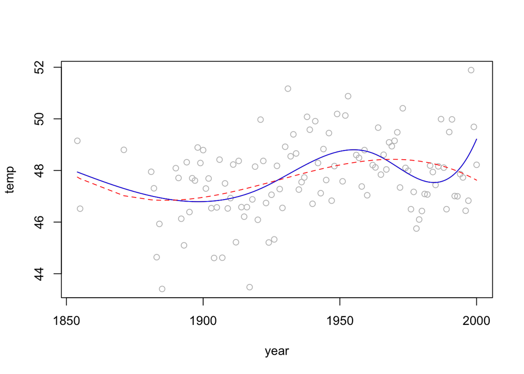

   ```r
   lines(aatemp$year,modp7$fit,col="red",lty=2) # cubic polynomial
   ```

   ```r
   sum((aatemp$temp-modp7$fit)^2) #RSS for the cubic polynomial model
   ```

   ```
   ## [1] 231.1398
   ```

   The cubic splines models has a lower RSS.

### Problem 2

Use the `odor` data from the *faraway* library for this question.

1. Fit a second order response surface for the odor response using the other three variables as predictors. How many parameters does this model use and how many degrees of freedom are left?

   ```r
   library(faraway)
   data(odor)
   names(odor)
   ```

   ```
   ## [1] "odor" "temp" "gas"  "pack"
   ```

   ```r
   head(odor)
   ```

   ```
   ##   odor temp gas pack
   ## 1   66   -1  -1    0
   ## 2   39    1  -1    0
   ## 3   43   -1   1    0
   ## 4   49    1   1    0
   ## 5   58   -1   0   -1
   ## 6   17    1   0   -1
   ```

   ```r
   attach(odor)
   p = polym(temp,gas,pack, degree=2)
   dim(p)
   ```

   ```
   ## [1] 15  9
   ```

   ```r
   odor.full = lm(odor~p, data=odor)
   summary(odor.full)
   ```

   ```
   ##
   ## Call:
   ## lm(formula = odor ~ p, data = odor)
   ##
   ## Residuals:
   ##        1        2        3        4        5        6        7        8
   ## -20.6250  -6.8750   6.8750  20.6250  15.5000   1.7500  -1.7500 -15.5000
   ##        9       10       11       12       13       14       15
   ##   5.1250 -22.3750  22.3750  -5.1250  -0.3333  -4.3333   4.6667
   ##
   ## Coefficients:
   ##             Estimate Std. Error t value Pr(>|t|)
   ## (Intercept)   15.200      5.804   2.619  0.04716 *
   ## p1.0.0       -34.295     22.479  -1.526  0.18761
   ## p2.0.0        61.991     22.603   2.743  0.04067 *
   ## p0.1.0       -48.083     22.479  -2.139  0.08542 .
   ## p1.1.0        66.000     89.914   0.734  0.49588
   ## p0.2.0        92.423     22.603   4.089  0.00946 **
   ## p0.0.1       -60.458     22.479  -2.690  0.04332 *
   ## p1.0.1        12.000     89.914   0.133  0.89903
   ## p0.1.1       -14.000     89.914  -0.156  0.88236
   ## p0.0.2        11.754     22.603   0.520  0.62524
   ## ---
   ## Signif. codes:  0 '***' 0.001 '**' 0.01 '*' 0.05 '.' 0.1 ' ' 1
   ##
   ## Residual standard error: 22.48 on 5 degrees of freedom
   ## Multiple R-squared:  0.882,  Adjusted R-squared:  0.6696
   ## F-statistic: 4.152 on 9 and 5 DF,  p-value: 0.06569
   ```

   We have 10 parameters in total, including the intercept.
2. Fit a model for the same response but now excluding any interaction terms but including linear and quadratic terms in all three predictors. Compare this model to the previous one. IS this simplification justified?

   ```r
    odor.reg = lm(odor~temp + gas + pack + I(temp^2) + I(gas^2)+ I(pack^2), data=odor)
   summary(odor.reg)
   ```

   ```
   ##
   ## Call:
   ## lm(formula = odor ~ temp + gas + pack + I(temp^2) + I(gas^2) +
   ##     I(pack^2), data = odor)
   ##
   ## Residuals:
   ##     Min      1Q  Median      3Q     Max
   ## -20.625  -9.625  -1.375   4.021  28.875
   ##
   ## Coefficients:
   ##             Estimate Std. Error t value Pr(>|t|)
   ## (Intercept)  -30.667     10.840  -2.829   0.0222 *
   ## temp         -12.125      6.638  -1.827   0.1052
   ## gas          -17.000      6.638  -2.561   0.0336 *
   ## pack         -21.375      6.638  -3.220   0.0122 *
   ## I(temp^2)     32.083      9.771   3.284   0.0111 *
   ## I(gas^2)      47.833      9.771   4.896   0.0012 **
   ## I(pack^2)      6.083      9.771   0.623   0.5509
   ## ---
   ## Signif. codes:  0 '***' 0.001 '**' 0.01 '*' 0.05 '.' 0.1 ' ' 1
   ##
   ## Residual standard error: 18.77 on 8 degrees of freedom
   ## Multiple R-squared:  0.8683, Adjusted R-squared:  0.7695
   ## F-statistic: 8.789 on 6 and 8 DF,  p-value: 0.003616
   ```

   ```r
   anova(odor.reg, odor.full)
   ```

   ```
   ## Analysis of Variance Table
   ##
   ## Model 1: odor ~ temp + gas + pack + I(temp^2) + I(gas^2) + I(pack^2)
   ## Model 2: odor ~ p
   ##   Res.Df    RSS Df Sum of Sq      F Pr(>F)
   ## 1      8 2819.9
   ## 2      5 2526.4  3     293.5 0.1936 0.8965
   ```

   Since the p-value is 0.8965, which is very large, we fail to reject the null hypothesis. So the simplification is justified.
3. Use the previous model to determine the values of the predictors which result in the minimum predicted odor.

   ```r
   id = which.min(odor.reg$fitted.values)
   odor[id,]
   ```

   ```
   ##    odor temp gas pack
   ## 13  -31    0   0    0
   ```